# Data Challenge 2: Dairy Cow Visualizations

Ziyan Hu

Due 5:59pm on Oct 9, 2023

link to the github: https://github.com/freyahu2000/Data-Science-1

```r
# load in the required libraries
library(readxl)
library(tidyverse)
library(janitor)
library(lubridate)
```

### Problem 1

We will be working with data from Mr. Trash Wheel, a water wheel trash collection device that removed trash from the Inner Harbor in Baltimore, Maryland. There are three trash wheels we will be exploring (Mr. Trash Wheel, Professor Trash Wheel, and Captain Trash Wheel). I have provided you the data for this on Canvas in the Excel spreadsheet titled `Trash-Wheel-Collection-Totals-8-6-19.xlsx.`

#### Solution

```r
# Read data from three trash wheels
mr_trash_wheel <- read_excel("data/Trash-Wheel-Collection-Totals-8-6-19.xlsx", sheet = "Mr. Trash Wheel")
```

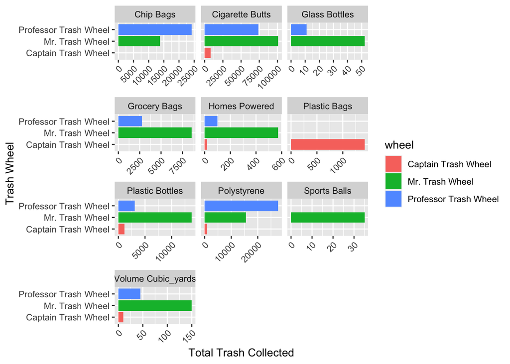

```r
professor_trash_wheel <- read_excel("data/Trash-Wheel-Collection-Totals-8-6-19.xlsx", sheet = "Professor Trash Wheel")
captain_trash_wheel <- read_excel("data/Trash-Wheel-Collection-Totals-8-6-19.xlsx", sheet = "Captain Trash Wheel")

# Prepare the data for Mr. Trash Wheel
mr_trash_wheel <- mr_trash_wheel %>%
  clean_names() %>%  # Clean the column names
  drop_na(dumpster) %>%  # Omit rows that do not include dumpster-specific data
  add_column(wheel = "Mr. Trash Wheel") %>%  # Create a new variable
  select(-x15, -x16, -x17)

# Repeat the same data preparation process for other trash wheels
professor_trash_wheel <- professor_trash_wheel %>%
  clean_names() %>%
  drop_na(dumpster) %>%
  add_column(wheel = "Professor Trash Wheel")

captain_trash_wheel <- captain_trash_wheel %>%
  clean_names() %>%
  drop_na(dumpster) %>%
  add_column(wheel = "Captain Trash Wheel")

# Bind the three dataframes together and pivot them to a long format
all_trash_wheel <- bind_rows(mr_trash_wheel,
                             professor_trash_wheel,
                             captain_trash_wheel) %>%
  pivot_longer(cols = -c(dumpster, wheel, year, month, date, weight_tons),
               names_to = "trash_type",
               values_to = "number")

# Clean up the trash_type variable
all_trash_wheel <- all_trash_wheel %>%
  mutate(trash_type = str_replace(trash_type, "_", " ")) %>%
  mutate(trash_type = str_to_title(trash_type))

# Create a new dataframe for trash totals in June 2018
all_trash_wheels_totals_June_2018 <- all_trash_wheel %>%
  filter(month == "June" & year == "2018") %>%
  group_by(wheel, trash_type) %>%
  summarise(total = sum(number),.groups = "drop")

# Create a faceted bar plot for trash totals in June 2018
all_trash_wheels_totals_June_2018 %>%
  ggplot(aes(x = total, y = wheel, fill = wheel)) +
  geom_bar(stat = "identity") +
  facet_wrap(~trash_type, nrow = 4, scales = "free_x") +
  labs(x = "Total Trash Collected",
       y = "Trash Wheel") +
  theme(axis.text.x = element_text(angle = 45, hjust = 1))
```

### Problem 2

Next we will be examining data from FiveThirtyEight on the S&P closing prices and the unemployment rate. For this problem, the data is provided on Canvas. You will need `snp.csv` and `unemployment.csv`.

#### Solution

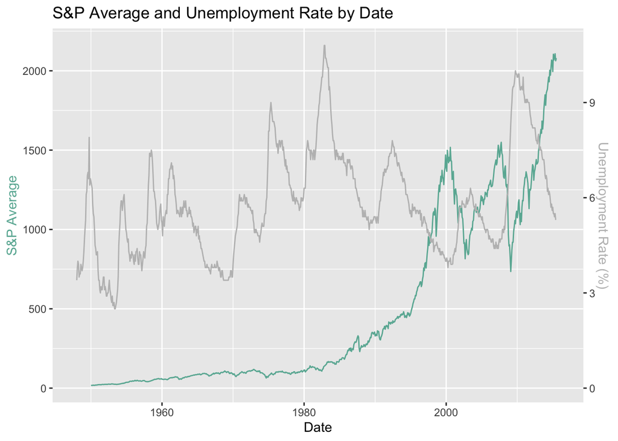

```r
# Read the S&P and unemployment data from CSV files
snp <- read.csv("data/snp.csv")
unemployment <- read.csv("data/unemployment.csv")

# Process the S&P data
snp <- snp %>%
  mutate(Date = mdy(date)) %>%
  mutate(Date = update(Date, year = ifelse(year(Date) >= 2050, year(Date) - 100, year(Date)))) %>%
  mutate(Year = year(Date)) %>%
  mutate(Month = month(Date, label = TRUE))

# Wrangle the unemployment data
unemployment <- unemployment %>%
  pivot_longer(-Year, names_to = "Month", values_to = "Rate") %>%
  mutate(Date = mdy(paste(Month, "01", Year)))

# Plot both the S&P average and the unemployment rate together on the same plot
snp_plot <- snp %>%
  ggplot(aes(x = Date, y = close)) +
  geom_line(color = "#69b3a2") +
  labs(y = "S&P Average", x = "Date", title = "S&P Average and Unemployment Rate by Date") +
  scale_y_continuous(sec.axis = sec_axis(~./200, name = "Unemployment Rate (%)")) +
  geom_line(data = unemployment, aes(x = Date, y = Rate * 200), color = "gray") +
  theme(
    axis.title.y = element_text(color = "#69b3a2"),
    axis.title.y.right = element_text(color = "gray")
  )

# Display the plot
print(snp_plot)
```

### Problem 3

Next we will examine the direct relationship between the S&P closing prices and the unemployment rate using data from 2000 and onward in a scatterplot.

#### Solution

```r
# Create a new data frame called snp_average to calculate the monthly mean of S&P close prices
snp_average <- snp %>%
  group_by(Year, Month) %>%
  summarise(Mean = mean(close),.groups = "drop") %>%
  mutate(Date = mdy(paste(Month, "01", Year)))

# Display the snp_average data frame
head(snp_average)
```

```
## # A tibble: 6 × 4
##    Year Month  Mean Date
##   <dbl> <ord> <dbl> <date>
## 1  1950 Jan    17.0 1950-01-01
## 2  1950 Feb    17.2 1950-02-01
## 3  1950 Mar    17.3 1950-03-01
## 4  1950 Apr    18.0 1950-04-01
## 5  1950 May    18.8 1950-05-01
## 6  1950 Jun    17.7 1950-06-01
```

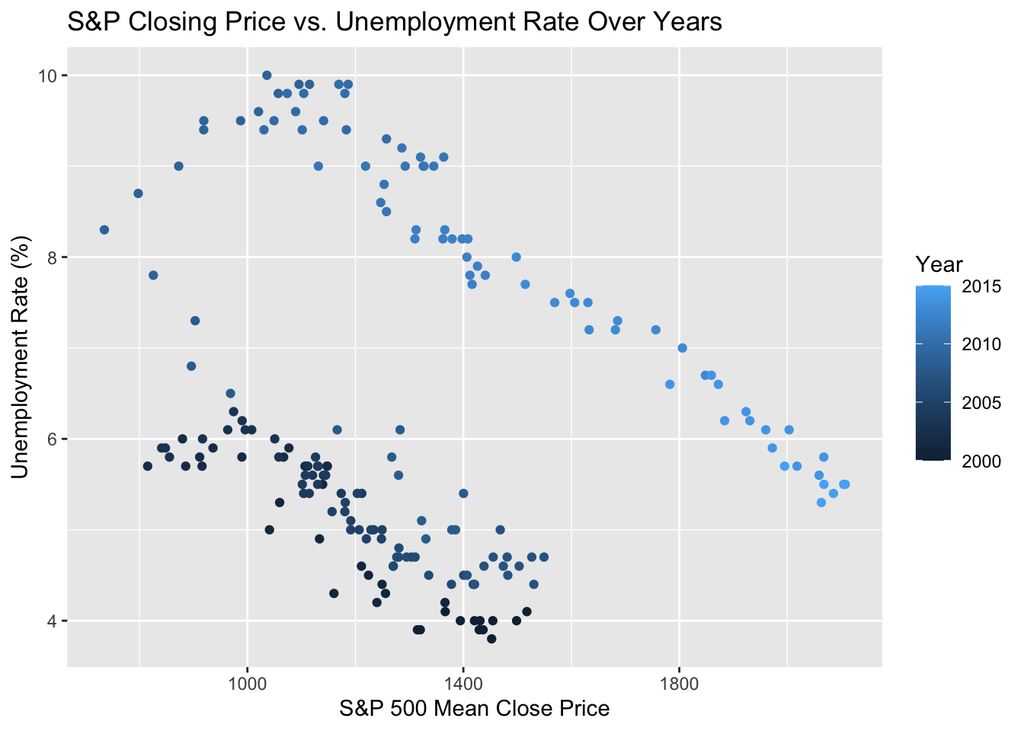

```r
# Join the unemployment data with snp_average based on Date, Month, and Year
joint_data <- right_join(unemployment, snp_average, by = c("Date", "Month", "Year")) %>%
  filter(Year >= 2000)

# Create a scatter plot to visualize the relationship between S&P 500 Mean Close Price and Unemployment Rate
joint_data %>%
  ggplot(aes(x = Mean, y = Rate, color = Year)) +
  geom_point() +
  labs(
    x = "S&P 500 Mean Close Price",
    y = "Unemployment Rate (%)",
    title = "S&P Closing Price vs. Unemployment Rate Over Years"
  )
```

### Problem 4

Write a paragraph (at least 5 sentences) describing what you observed in the plots in Problems 2 & 3.

#### Solution

The line plot in Problem 2 focus on comparing the S&P closing price and unemployment rate. Before 1990, we can see unemployment rate fluctuated and S&P closing price stay low, and they have no obvious relationship. After 2000, we can see that the inverse relationship is apparent. As the S&P closing price rises, the unemployment rate tends to fall; As the S&P closing price falls, the unemployment rate tends to rise.

The scatterplot created in Problem 3 focuses on comparing the S&P mean closing price against the unemployment rate from 2000. Each point represents a month, with the points colored by year. The downward slope of the point cloud shows the consistent inverse correlation between the two variables. However, the spread of the points across years indicates that the strength of the relationship varies over time. Overall, these plots effectively illustrate the connection between stock market performance and unemployment in the U.S. economy. As market returns increase, unemployment decreases; As market returns decrease, unemployment increases.